# Channel Head Temp Report 7_18_19

Like last time, here is a little report with some plots of what I’ve looked at so far! With this document should be a link to the git repository this is in, as well as a copy of the spreadsheet with all of the data formatted! I have also included code to convert the data (which is tall in the csv) into the wide format I’ve used in the past before I knew the wonders of tidyr!

A brief recap: The stream temperature sensors were all collected the other day after being deployed for 25 days, and I’ve been playing around with the data. The sensors collected the temp every 10 minutes. 2 sensors were deployed at the channel head and ~200 m downstream. Additionally, an air temp was recorded at the head of one of the channels in each watershed.

Data time period  
Start date: 6-13-19 13:10  
End date: 7-8-19 11:20

MUL = Mull Creek, high elevation ~ 1600 m  
RMO = Moses Creek, med elevation ~ 1300 m  
ULB = Long Branch, mid/low elev ~ 850 m  
GG = Gribble Gap, low elev ~ 700 m

Removed Data- Data was removed for being weird (values of -53 C!), or obviously not in water for a significant period of time  
LS180B: 3763, 3764  
removed LS180A  
removed W600A  
GC300A sensor is missing  
removed ULB4HB  
removed MUL4HB, 4CB is missing  
removed MUL7HA  
RMO3HA missing- appears to have been in data before, gone now, but still have RMO3HB

```r
#read in formatted tall data
master.tall <- read.csv("Formatted.temps.tall_7_17.csv")
master.tall$rnd.dates <-ymd_hms(master.tall$rnd.dates)
#convert tall data to wide- how I have sent you temp data in the past
master.spread <- select(master.tall, Value, rnd.dates, site)
master.spread <- master.spread %>% spread(site, value = Value)
```

Basic temperature trends/timeseries

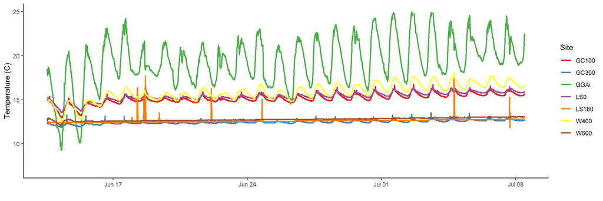

```r
#filtering out duplicate sites/sensors- just for this plotting
all.ts <- c("ULB2HA","ULB3HA", "ULB4HA", "RMO1HA", "RMO2HA", "RMO3HB", "MUL2HA",  "MUL4HB",  "MUL7HB", "W600B", "GC300B", "LS180B","ULB2CB", "ULB3CB", "ULB4CA", "RMO1CB",  "RMO2CB",  "RMO3CB", "MUL2CB", "MUL4CA",  "MUL7CA", "W400A", "GC100B",  "LS0B", "MULAir", "GGAir", "RMOAir", "ULBAir")

one.sens <- master.tall %>% filter(site %in% all.ts)
one.sens$site <- gsub('.{1}$', '', one.sens$site)
timeseries <- one.sens

mul.ts <- timeseries %>% filter(shed == "MUL")
ulb.ts <- timeseries %>% filter(shed == "ULB")
gg.ts <- timeseries %>% filter(shed == "GG")
rmo.ts <-

mul.ts2 <- timeseries %>% filter(shed == "MUL" & type != "air")
ulb.ts2 <- timeseries %>% filter(shed == "ULB" & type != "air")
gg.ts2 <- timeseries %>% filter(shed == "GG" & type != "air")

#gg with airT
gg.ts.plot <- ggplot(data = gg.ts,
                      aes(x = rnd.dates,
                          y = Value,
                          color = site))+
  geom_line(size = 1)+
  scale_color_brewer(palette = "Set1",
                     name = "Site")+
  xlab(" ")+
  ylab("Temperature (C)")+
  ylim(7,25)+
  theme_classic()
gg.ts.plot
```

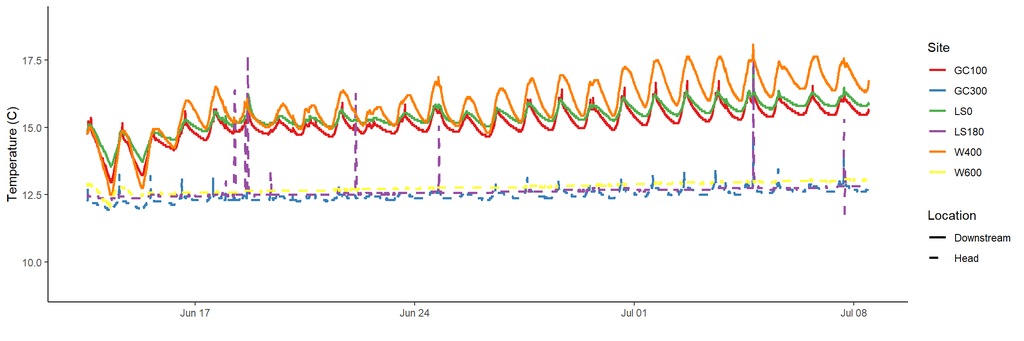

```r
#gg without airT
gg.ts.plot2 <- ggplot(data = gg.ts2,
                       aes(x = rnd.dates,
                           y = Value,
                           color = site,
                           linetype = type))+
  geom_line(size = 1)+
  scale_color_brewer(palette = "Set1",
                     name = "Site")+
  scale_linetype_manual(labels = c("Downstream", "Head"),
                        values=c("solid", "dashed"),
                        name = "Location")+
  xlab(" ")+
  ylab("Temperature (C)")+
  ylim(9,19)+
  theme_classic()
gg.ts.plot2
```

Plots of Gribble Gap timeseries- first with AirT, second without AirT ~700 m

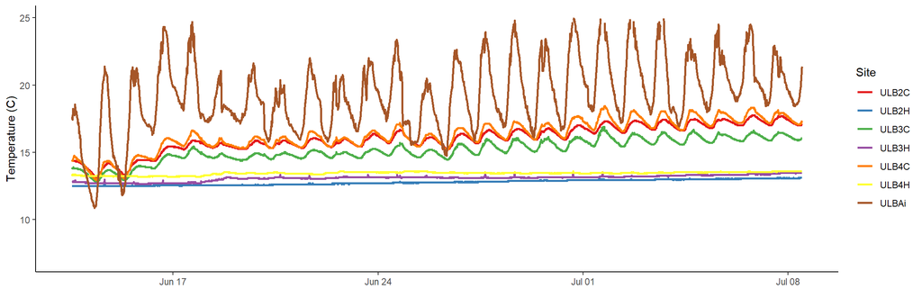

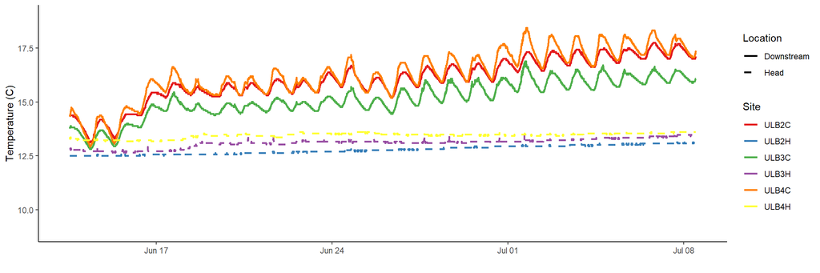

**Plots of Long Branch timeseries- first with AirT, second without AirT**

850 m

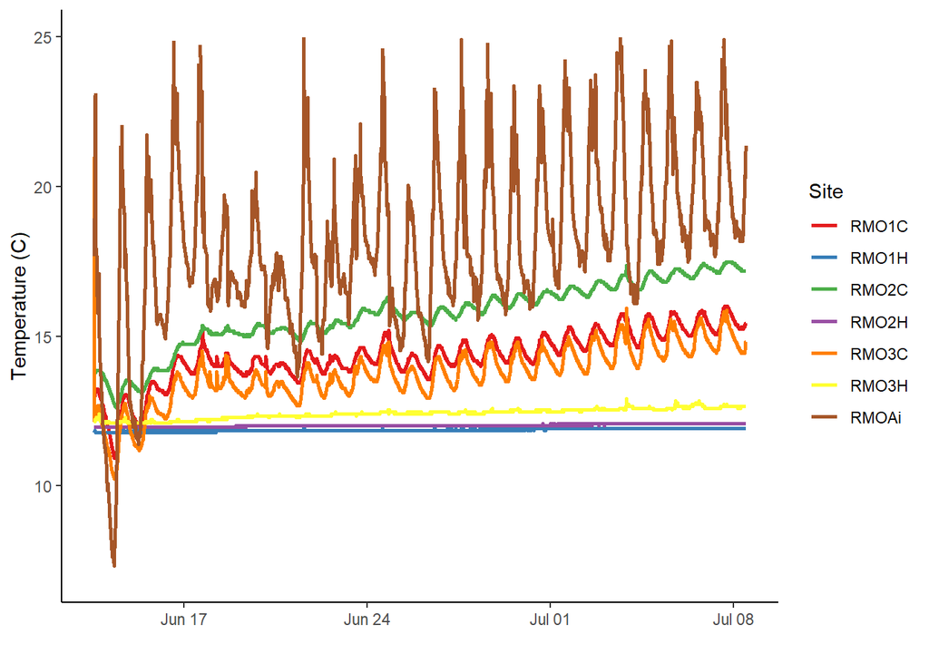

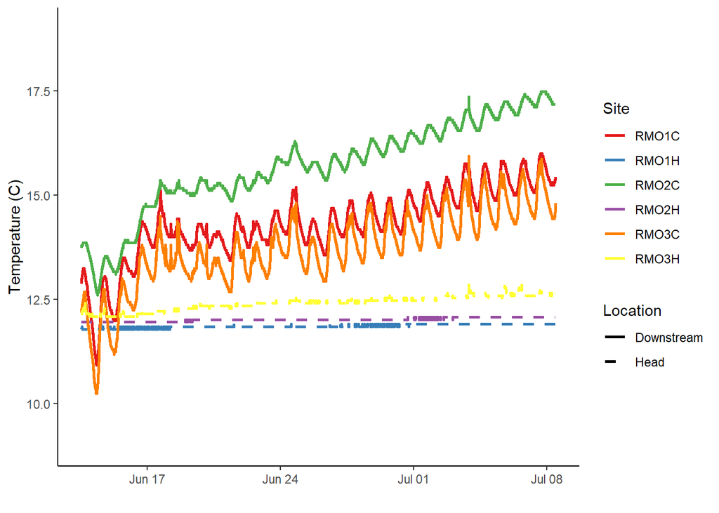

Plots of Moses Creek timeseries- first with AirT, second without AirT ~ 1300 m

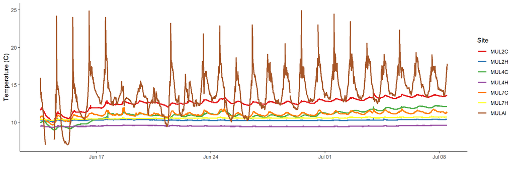

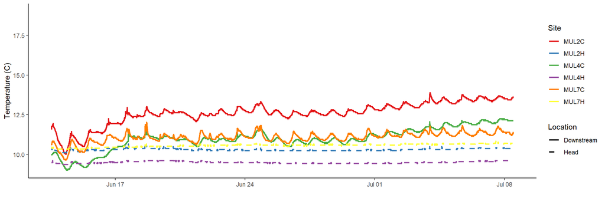

Plots of Mull Creek timeseries- first with AirT, second without AirT ~ 1600 m

Plots of diff between downstream and head vs air- sort of like contour lines, the closer the lines are together the denser the points would be- just having points didn’t display these relationships very well

Gribble Gap ~700m

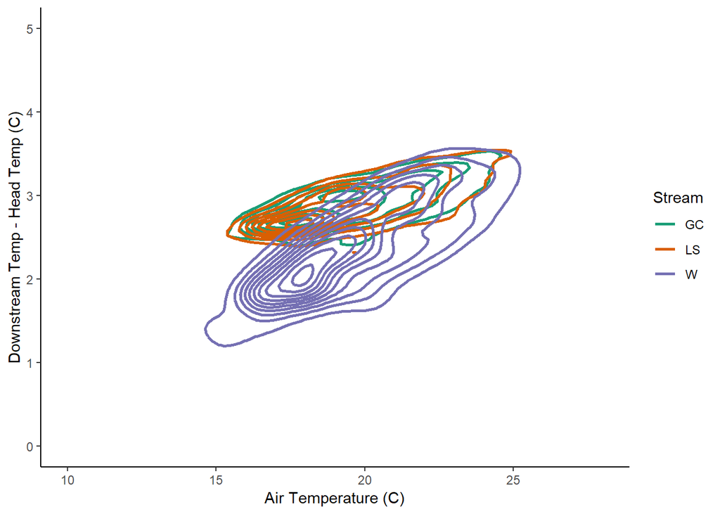

```r
#make data frames with differences
#easiest way I could devise was by using the wide/spread data
attach(master.spread)
ulb.diffs <- data.frame("ULB2"= ULB2CA - ULB2HA,
                        "ULB3"= ULB3CA - ULB3HA,
                        "ULB4"= ULB4CA - ULB4HA,
                        "ULBAir" = ULBAir)
rmo.diffs <- data.frame("RMO1" = RMO1CA - RMO1HA,
                        "RMO2" = RMO2CA - RMO2HA,
                        "RMO3" = RMO3CA - RMO3HB,
                        "RMOAir" = RMOAir)
mul.diffs <- data.frame("MUL2" = MUL2CA - MUL2HA,
                        "MUL4" = MUL4CA - MUL4HB,
                        "MUL7" = MUL7CA - MUL7HB,
                        "MULAir" = MULAir)
gg.diffs <- data.frame("GGAir" = GGAir,
                       "W" = W400A - W600A,
                       "GC" = GC100A - GC300B,
                       "LS" = LS0B - LS180B)
detach(master.spread)

#make em tall- wtih ULBAir as the spreader
ulb.tall.diffs <- ulb.diffs %>% gather(site, temp, -ULBAir)
gg.tall.diffs <- gg.diffs %>% gather(site, temp, -GGAir)
rmo.tall.diffs <- rmo.diffs %>% gather(site, temp, -RMOAir)
mul.tall.diffs <- mul.diffs %>% gather(site, temp, -MULAir)

gg.diff.plot <- ggplot(data = gg.tall.diffs,
                       aes(x = GGAir,
                           y = temp,
                           color = site))+
  scale_color_brewer(palette = "Dark2",
                     name = "Stream")+
  stat_density2d(size = 1, na.rm = T)+
   xlim(10, 28)+
  ylim(0,5)+
  ylab("Downstream Temp - Head Temp (C)")+
  xlab("Air Temperature (C)")+
  theme_classic()
gg.diff.plot
```

Long Branch diff plot ~ 850 m

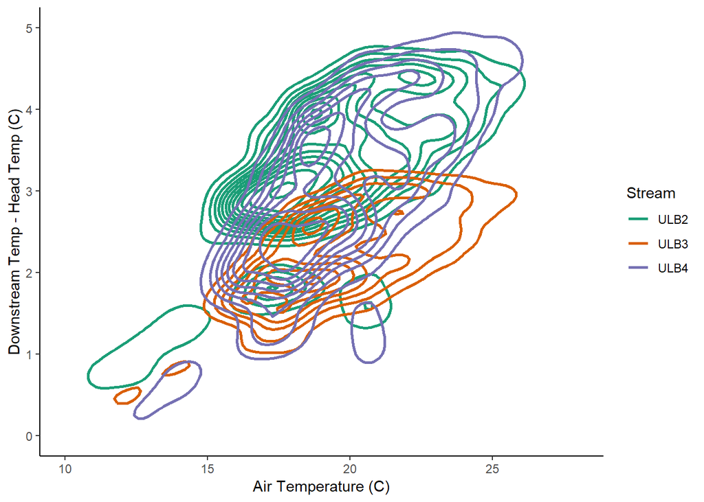

Moses Creek diff plot ~ 1300 m

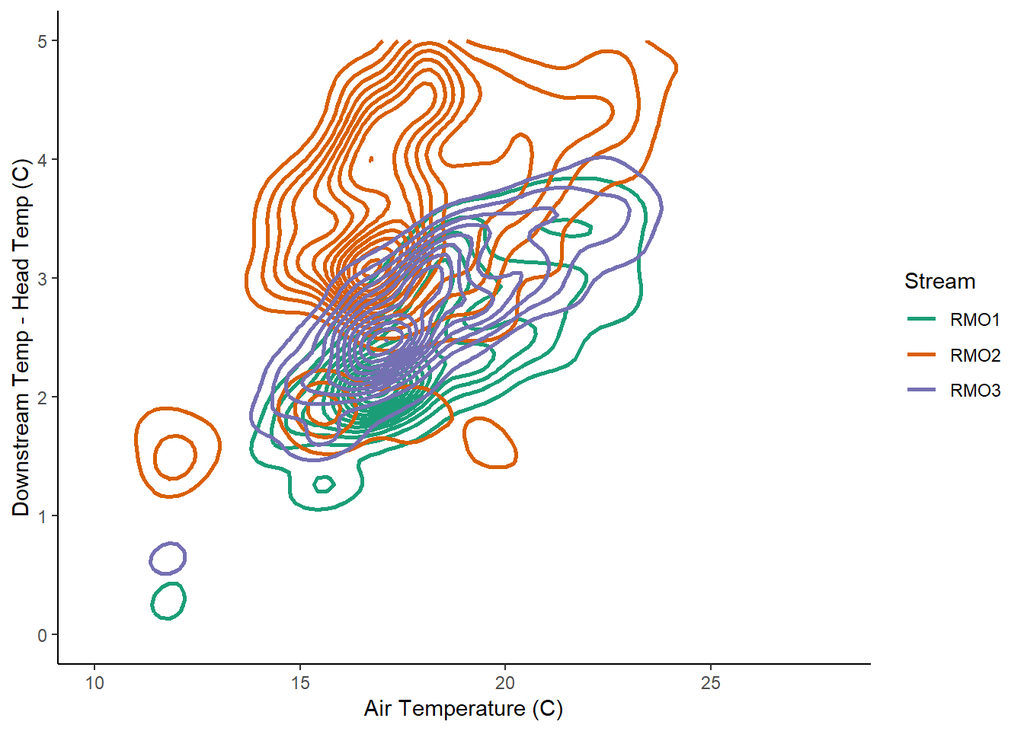

Mull Creek diff plot~ 1600 m

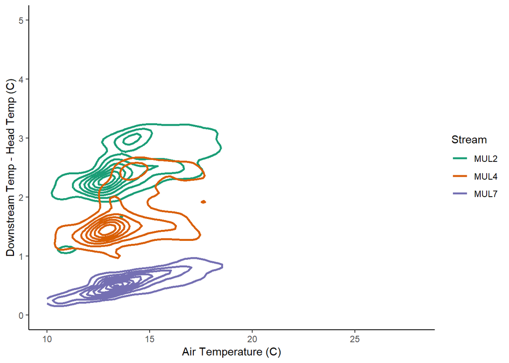

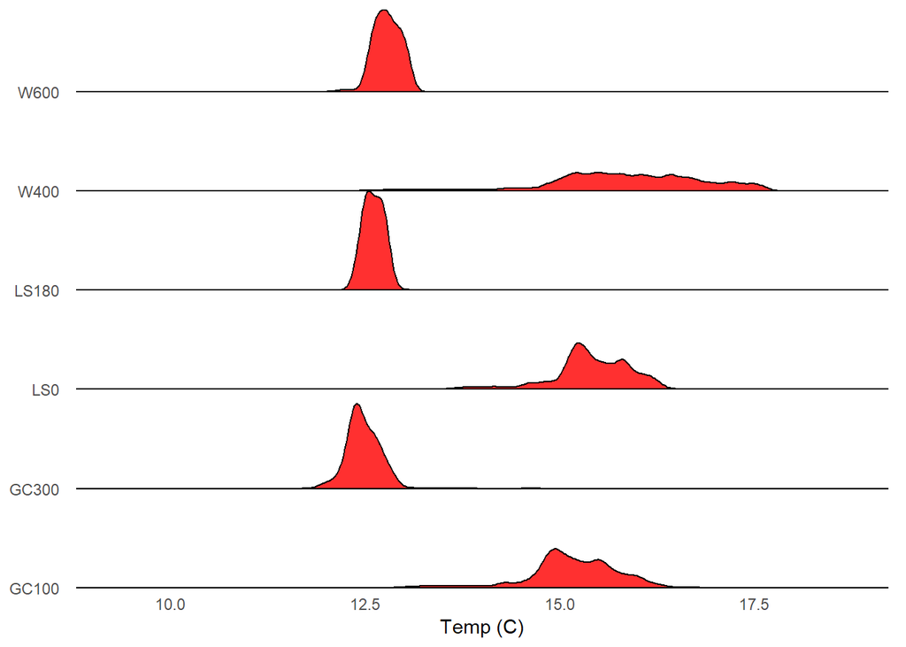

```r
gg.r <- c("W600B", "W400A", "GC300B","GC100B", "LS180B", "LS0B")
#subset master dataset
gg.r <- filter(master.tall, site %in% gg.r)
#remove A/B from site names
gg.r$site <- gsub('.{1}$', '', gg.r$site)

#adding fudged numbers to fix the x limits- trying to set an xlim on these plots messes them up
gg.r$Value[100] <- 9
gg.r$Value[200] <- 19
#make ridge plots
gg.ridge <- ggplot()+
  geom_density_ridges2(gg.r,fill = c('firebrick1'),
                      mapping = aes(x = Value,
                                    y=site,
                                    scale=1), na.rm = T)+
  theme_classic()+
  theme(axis.title.y=element_blank(),
        #axis.title.x=element_text(size = 17),
        axis.ticks.y=element_blank(),
        strip.text.y = element_text(angle = 180, hjust = 1),
        line = element_blank())+
        #axis.text.x = element_text(size = 17),
        #axis.text.y = element_text(size = 17))+
  scale_x_continuous( expand = c(0.01, 0)) +
  scale_y_discrete(expand = c(0.001, 0))+
  xlab("Temp (C)")
gg.ridge
```

Moses Creek Temp distributions ~ 1300 m

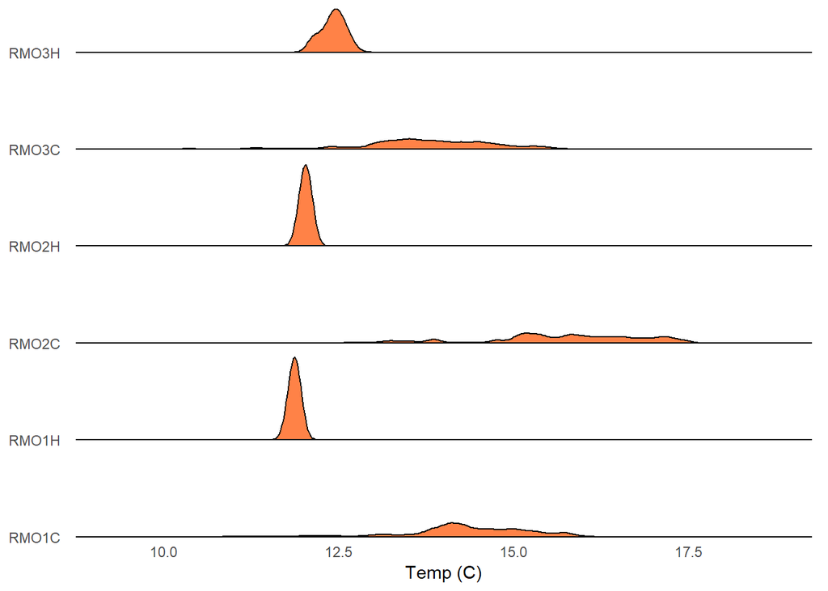

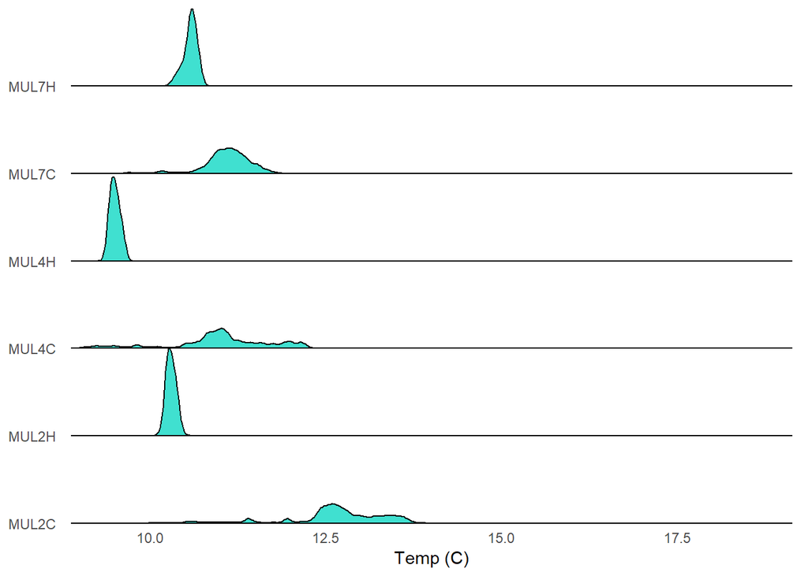

Overall, this temperature data is looking really cool! I’m currently working on getting my topographic metrics (slope, drainage area, curvature) organised and then I’m going to slap together with the temperatures. This summer program is winding to a close and I have to do some other things for it so I’ve had to prioritize that temporarily.

Trends that we were expecting and saw were the very constant temps at the heads, and that the head temps vary with elevation- the highest elevation sites (Mull creek) have the lowest head temps.

Let me know what you think! And if you make any sick plots with the data!